# R / Shiny User Poll

Casimir Saternos

December 25, 2015

A total of 377 people responded to the survey.

```
##
##        2 - 5 years       5 - 10 years   Less than 1 year More than 10 years
##                197                 90                 56                 34
```

## Response Time

Most of the responses were recieved in the first two days. This corresponds with the length of time that it was on the front page of http://r-bloggers.com.

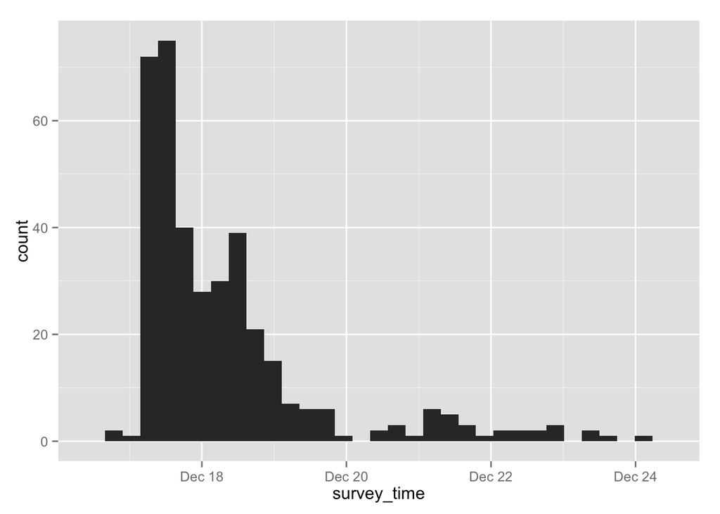

## Length of R Usage

More than 1/2 the respondents have been using R for 5 years or less.

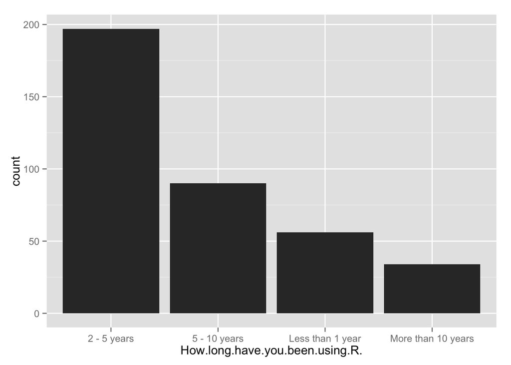

## Roles

Respondents serve in a variety of roles - many in more than one.

| Role | Freq |
| --- | --- |
| data scientist | 206 |
| statistician | 118 |
| scientist social scientist | 100 |
| university student | 91 |
| software developer | 82 |
| online course mooc student | 69 |
| database administrator | 20 |
| data analyst | 5 |
| engineer | 3 |
| analyst | 2 |
| professor | 2 |

In addition to these resposes, there were a large variety of roles that were written in once (“actuary”, “and scientist social scientist i may be all 3”, “assistant”, “auditor dataanalyst”, “bi analyst”, “bioinformatician”, “business analyst”, “business analytics”, “business user consultant”, “capacity planning”, “computer science faculty”, “consultant”, “course instructor”, “data manager”, “epidemiologist”, “farmer agricultural producer”, “financial auditor”, “financial consultant”, “fun explorations”, “i am a dean of a small college”, “insight manager and reporting”, “intelligence analyst”, “life insurance”, “manager of data science team”, “masters student”, “need analyse our data”, “need clarity about the differences between statistician”, “operations research”, “personal sanity”, “ph d”, “physician”, “portfolio manager”, “psychologist”, “research”, “research engineer”, “scientific research”, “spatial data analyst”, “statistics course instructor”, “teacher”, “university lecturer”, “university teacher”, “warranty engineer”, “wind analyst”)).

## Platforms

The breakdown by platform shows interesting usage patterns.

| On.what.platform.s..do.you.run.R. | count |
| --- | --- |
| Linux | 32 |
| Linux, Mac / OSX | 16 |
| Linux, Mac / OSX, Windows | 31 |
| Linux, Windows | 104 |
| Mac / OSX | 34 |
| Mac / OSX, Windows | 33 |
| Windows | 127 |

The width of the bars of the chart below represent the count of users on each platform combination. The most common responses were windows alone, followed by windows and linux. These two responses comprise 61.27 of all responses.

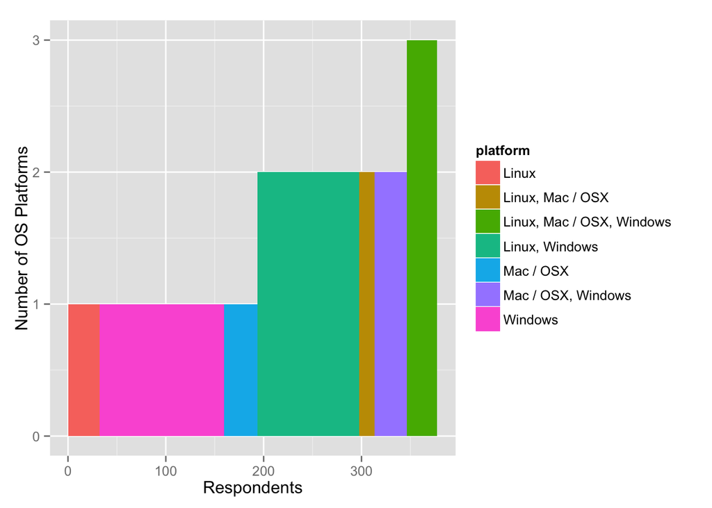

Users that don’t use Windows at all but use both OSX and Linux are the smallest group, and relatively few users use linux and OSX exclusively. Windows usage is broken out in the following plot which represents non-windows users on the left and windows users on the right.

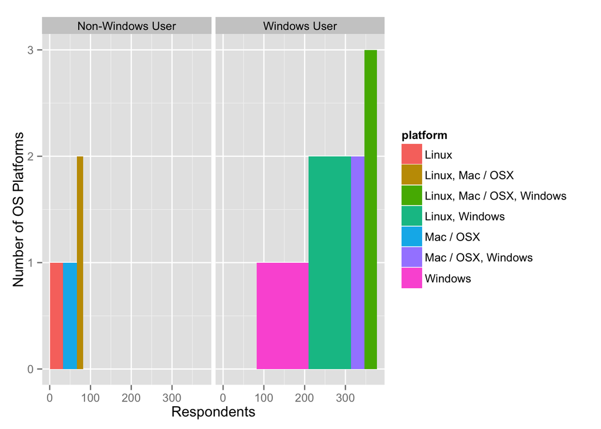

# Web Technology Experience

| Var1 | Freq |
| --- | --- |
| None | 128 |
| HTML, JavaScript, CSS, Server Side Technologies (.NET, Java, PHP, Ruby on Rails, etc) | 66 |
| HTML, JavaScript, CSS | 57 |
| HTML | 45 |
| HTML, CSS | 18 |
| HTML, JavaScript | 16 |
| Server Side Technologies (.NET, Java, PHP, Ruby on Rails, etc) | 13 |
| HTML, Server Side Technologies (.NET, Java, PHP, Ruby on Rails, etc) | 8 |
| HTML, CSS, Server Side Technologies (.NET, Java, PHP, Ruby on Rails, etc) | 7 |
|  | 4 |
| HTML, JavaScript, Server Side Technologies (.NET, Java, PHP, Ruby on Rails, etc) | 4 |
| JavaScript | 3 |
| CSS | 2 |
| HTML, None | 2 |
| JavaScript, CSS | 2 |
| HTML, JavaScript, None | 1 |
| JavaScript, Server Side Technologies (.NET, Java, PHP, Ruby on Rails, etc) | 1 |

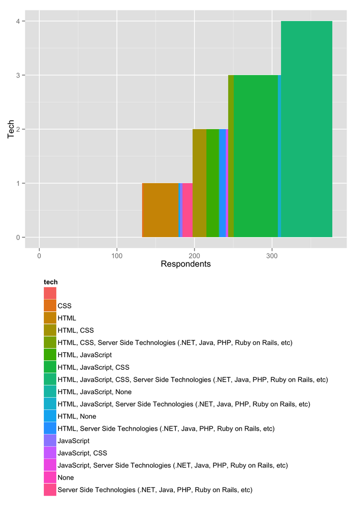

## Raw Data

[Google Spreadsheet](https://docs.google.com/spreadsheets/d/1Gm3jTIHs2TGMXoz84_DyuTBd3auGY3iJ3jzjQNExl5Q/edit?usp=sharing)

## Issues with Poll Results

- Question 1, choice of less than one year, then 2 through 5 years. One to two years not convered.
- Responses to Web Tech included None option. Perhaps should have omitted this answer and let the question response be optional.